# Fisseha Berhane, PhD

#### Selecting columns

*select* selects a set of columns with names or Column expressions.

```r
select(flights, flights$year, flights$month, flights$day)%>%showDF(numRows =15,truncate = FALSE)
```

```
+----+-----+---+
|year|month|day|
+----+-----+---+
|2013|1    |1  |
|2013|1    |1  |
|2013|1    |1  |
|2013|1    |1  |
|2013|1    |1  |
|2013|1    |1  |
|2013|1    |1  |
|2013|1    |1  |
|2013|1    |1  |
|2013|1    |1  |
|2013|1    |1  |
|2013|1    |1  |
|2013|1    |1  |
|2013|1    |1  |
|2013|1    |1  |
+----+-----+---+
only showing top 15 rows
```

```r
# select(flights, c("year", "month", "day")   this also gives the same result
```

#### Getting distinct records

*distinct* returns a new DataFrame containing the distinct rows in this DataFrame.

```r
distinct(select(flights, flights$tailnum))%>%dim()  # See how many distinct 'tailnum' we have
```

```
[1] 4044    1
```

#### Adding new columns

*withColumn* returns a new DataFrame with the specified column added.

```r
 withColumn(flights,'gain', flights$arr_delay - flights$dep_delay)%>%
  select(c('year','month','day','gain'))%>%
  showDF(numRows =8,truncate = FALSE)
```

```
+----+-----+---+-----+
|year|month|day|gain |
+----+-----+---+-----+
|2013|1    |1  |9.0  |
|2013|1    |1  |16.0 |
|2013|1    |1  |31.0 |
|2013|1    |1  |-17.0|
|2013|1    |1  |-19.0|
|2013|1    |1  |16.0 |
|2013|1    |1  |24.0 |
|2013|1    |1  |-11.0|
+----+-----+---+-----+
only showing top 8 rows
```

#### Sampling

*Sample* returns a sampled subset of this DataFrame using a random seed.

```r
collect(sample(flights, FALSE, 0.00005))  # Sample without replacement
```

```
   year month day dep_time dep_delay arr_time arr_delay carrier tailnum
1  2013     1  14      642        -3      858        12      US  N565UW
2  2013     1  25     1204        -1     1313       -12      WN  N291WN
3  2013    10  15     1758        -2     2017       -13      DL  N337NB
4  2013    12  14     2035       125      132       223      DL  N3758Y
5  2013    12  28     1733         3     2055         0      AA  N344AA
6  2013     3   5     1932         3     2129        -1      EV  N12167
7  2013     4  15      734        14     1004        29      WN  N340LV
8  2013     4  17      855        -5     1017        -8      US  N750UW
9  2013     4  23      754        -1      924        14      MQ  N804MQ
10 2013     4  27     1603        -2     1908       -16      DL  N365NB
11 2013     5   2     1558        -1     1804       -10      MQ  N659MQ
12 2013     5  16     1650        -9     1835       -31      9E  N8847A
13 2013     6   7     1117        64     1320        65      EV  N16183
14 2013     6  25     1257         6     1448        -2      DL  N369NB
```

[output cut: 25 more lines]

```r
collect(sample(flights, TRUE, 0.00005))  # Sample with replacement
```

```
   year month day dep_time dep_delay arr_time arr_delay carrier tailnum
1  2013    10  30      730       -15     1031       -12      B6  N630JB
2  2013    10  30     1506        -9     1808        -2      AA  N587AA
3  2013    11   1      640         0      838         0      EV  N14203
4  2013    12  19     1828        -2     2030       -17      EV  N751EV
5  2013    12  23     1023        24     1252        24      9E  N8501F
6  2013     2   5      852        -7     1136        -9      DL  N642DL
7  2013     2   7     1326        -4     1611         6      DL  N37700
8  2013     2  24      723        -9     1022       -16      UA  N429UA
9  2013     4   2      631         1      747        -2      EV  N16918
10 2013     4  14      849        -6     1035       -34      DL  N766NC
11 2013     4  19     1811        31     1950        15      WN  N785SW
12 2013     4  26     1830       118     2020       129      EV  N13161
13 2013     6  14     2228        63       44        45      UA  N440UA
14 2013     6  30      835         0      951       -14      EV  N13913
```

[output cut: 19 more lines]

#### Counting number of records

Count the number of records for each group:

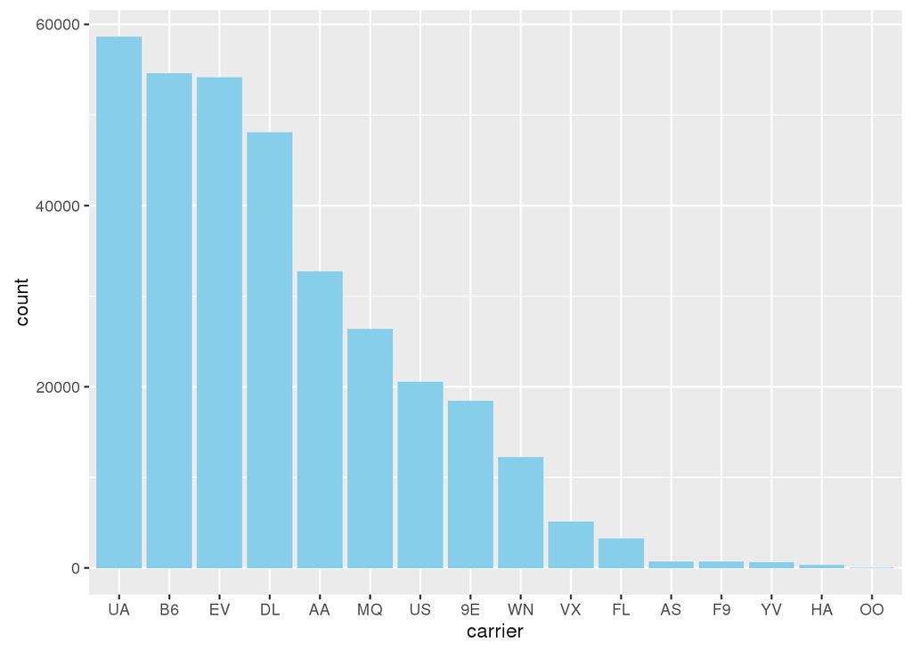

```r
count(groupBy(flights, "carrier"))%>%collect()%>% dplyr::mutate(carrier=factor(carrier,levels = carrier[order(count,decreasing =T)]))%>%
  ggplot(aes(x=carrier, y=count))+geom_bar(stat="identity",fill='sky blue')
```

#### Aggregating

```r
agg(group_by(flights, flights$carrier),
                    count = n(flights$carrier), maximum =max(flights$distance),
                    minimum =min(flights$distance),mean =mean(flights$distance),
                    sample_standard_deviation=stddev_samp(flights$distance)
    )%>%showDF()
```

```
+-------+-----+-------+-------+------------------+-------------------------+
|carrier|count|maximum|minimum|              mean|sample_standard_deviation|
+-------+-----+-------+-------+------------------+-------------------------+
|     AA|32729|    944|   1005|1340.2359986556264|         637.736152529242|
|     HA|  342|   4983|   4983|            4983.0|                      0.0|
|     AS|  714|   2402|   2402|            2402.0|                      0.0|
|     B6|54635|    997|   1005| 1068.621524663677|         703.705659773323|
|     UA|58665|    997|   1008|1529.1148725816074|        798.8046815611141|
|     US|20536|     96|     17| 553.4562719127387|        583.8225238535786|
|     OO|   32|    733|   1008|          500.8125|        206.1722482967626|
|     VX| 5162|   2586|   2248|2499.4821774506004|         88.0488899750204|
|     WN|12275|    888|   1167|  996.269083503055|       410.42960818312923|
|     DL|48110|    963|   1005|1236.9012055705675|        660.1724143675561|
|     EV|54173|    997|   1008|    562.9917301977|       287.48815905858027|
|     F9|  685|   1620|   1620|            1620.0|     1.137426313741963...|
|     9E|18460|    964|   1005|  530.235752979415|       321.79870716218636|
|     YV|  601|     96|    229| 375.0332778702163|       159.71957370363523|
|     FL| 3260|    762|    397| 664.8294478527607|        160.8880361106722|
|     MQ|26397|    888|   1005| 569.5327120506118|        226.2287070772906|
+-------+-----+-------+-------+------------------+-------------------------+
```

#### Writing data to file

Save as CSV:

```r
sampled =sample(flights, FALSE, 0.01)
write.df(sampled, "I_sampled_it", "com.databricks.spark.csv", mode = "overwrite")
```

Save as parquet

```r
write.df(sampled, "I_sampled_it", "parquet", "overwrite")
```

We can also save the contents of a DataFrame as a Parquet file, preserving the schema, using write.parquet. Files written out with this method can be read back in as a DataFrame using read.parquet().

What if we want to save the contents of a DataFrame as a JSON file.

```r
write.json(sampled, "I_sampled_it")
```

Note: files written out with this method can be read back in as a DataFrame using *read.json()*.

#### Finally, terminate SparkR

```r
sparkR.stop()
```

[comments powered by Disqus](http://disqus.com)